# Workshop

I. Moustakas

Compiled: mei 30, 2025

# R markdown

This is an Rmarkdown document. In a nutshell, it combines narrative text and R code to produce an easy to read and follow output. You can read more on the principles and use of it here: https://rmarkdown.rstudio.com/

# Setup

## Load the necessary libraries

```r
suppressMessages(library(Seurat))
suppressMessages(library(dplyr))
suppressMessages(library(ggplot2))
```

## Load the dataset

By just running the loaded object, we get some basic information about it: it has 57490 features (genes) across 838 samples (cells)

- Note you need to provide the location of `tyser.rds` in your own machine

```r
object <- readRDS("/home/imoustakas/Documents/anatomy_workshop/tyser.rds")
object
```

```
## An object of class Seurat
## 57490 features across 838 samples within 1 assay
## Active assay: RNA (57490 features, 4000 variable features)
##  3 layers present: counts, data, scale.data
##  2 dimensional reductions calculated: pca, umap
```

# Analysis tasks

## Explore the object meta data

The [Seurat object](https://rdrr.io/cran/SeuratObject/man/Seurat-class.html) is a representation of single-cell expression data for R. It stores the raw and normalized count table, low dimensional representations of the cells (PCA, UMAP, tSNE), some cell meta data and more. For this workshop we will explore the meta data, which is the most useful

- The cell metadata is basically a table. What do rows and columns represent?

```r
head(object[[]], n=10)
```

```
##                 orig.ident nCount_RNA nFeature_RNA  Source.Name
## SS.sc7785290 SeuratProject     377152         4922 SS.sc7785290
## SS.sc7786612 SeuratProject     259889         6942 SS.sc7786612
## SS.sc7786605 SeuratProject     437911         6140 SS.sc7786605
## SS.sc7788091 SeuratProject     298218         5030 SS.sc7788091
## SS.sc7785785 SeuratProject     362622         4259 SS.sc7785785
## SS.sc7785611 SeuratProject     604384         5249 SS.sc7785611
## SS.sc7786076 SeuratProject     299897         5626 SS.sc7786076
## SS.sc7785704 SeuratProject     377164         4001 SS.sc7785704
## SS.sc7785425 SeuratProject     489189         5905 SS.sc7785425
## SS.sc7786250 SeuratProject     447412         5622 SS.sc7786250
##              Characteristics.sampling.site.
## SS.sc7785290                       yolk sac
## SS.sc7786612                        rostral
## SS.sc7786605                        rostral
## SS.sc7788091                         caudal
## SS.sc7785785                         caudal
## SS.sc7785611                        rostral
## SS.sc7786076                         caudal
## SS.sc7785704                         caudal
## SS.sc7785425                       yolk sac
## SS.sc7786250                         caudal
##              Characteristics.inferred.cell.type...authors.labels.
## SS.sc7785290                     hemogenic endothelial progenitor
## SS.sc7786612                                      endodermal cell
## SS.sc7786605                                    advanced mesoderm
## SS.sc7788091                                       axial mesoderm
## SS.sc7785785                                          erythrocyte
## SS.sc7785611                                      endodermal cell
## SS.sc7786076                                        epiblast cell
## SS.sc7785704                                     primitive streak
## SS.sc7785425                                    yolk sac mesoderm
## SS.sc7786250                                    advanced mesoderm
##              Characteristics.inferred.cell.type...ontology.labels.
## SS.sc7785290                                         hemangioblast
## SS.sc7786612                                       endodermal cell
## SS.sc7786605                                         mesoderm cell
## SS.sc7788091                                 chordamesodermal cell
## SS.sc7785785                                           erythrocyte
## SS.sc7785611                                       endodermal cell
```

[output cut: 11 more lines]

```
## SS.sc7786076                          Epiblast          Epiblast  1.8849803
## SS.sc7785704                  Primitive Streak  Primitive Streak  1.5995694
## SS.sc7785425                      ExE Mesoderm       YS Mesoderm  0.9104776
## SS.sc7786250                 Advanced Mesoderm Advanced Mesoderm  1.1737739
##              percent.dissoc RNA_snn_res.1 seurat_clusters
## SS.sc7785290     0.01477381             3               3
## SS.sc7786612     0.01004373             9               9
## SS.sc7786605     0.01275764             4               4
## SS.sc7788091     0.01204888            13              13
## SS.sc7785785     0.01549633            12              12
## SS.sc7785611     0.01263665             6               6
## SS.sc7786076     0.01069320             2               2
## SS.sc7785704     0.01216059             1               1
## SS.sc7785425     0.01652165             8               8
## SS.sc7786250     0.01268859             4               4
```

### UMAP

You have just loaded an already analyzed data set. The cells have been clustered and the their 2d representation has been calculated using UMAP. Simply plot the UMAP to visualize the clusters

- We save the plot as a pdf file using `ggsave`

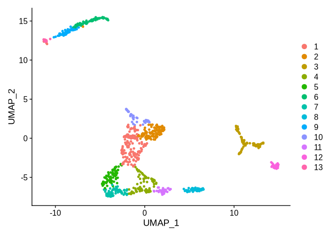

```r
DimPlot(object=object,
        reduction="umap")
```

```r
# Save the plot as PDF
ggsave("umap.pdf")
```

### Another cell attribute on UMAP

Is any of the meta data columns (cell attributes) of your interest? Plot it on the UMAP. Cells will be then colored according to it

- Look at the documentation of `DimPlot` by typing `?Dimplot` in the console. How can you achieve the above?

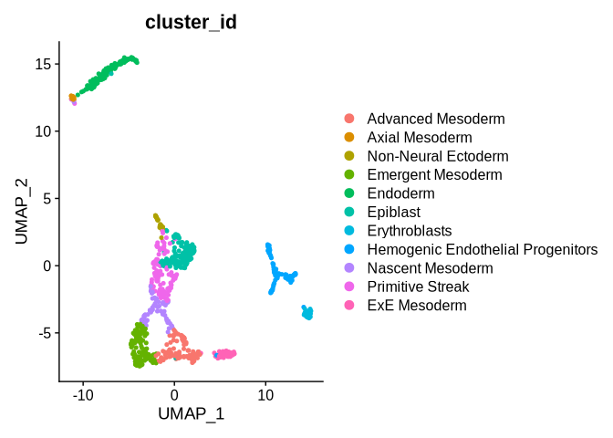

```r
DimPlot(object=object,
        reduction="umap",
        group.by="cluster_id")
```

## Discover marker genes

Seurat can help you find markers that define clusters via differential expression. By default, it identifies positive and negative markers of a single cluster (specified in `ident.1`), compared to all other cells. In this example the DEGs of cluster 5 vs all the rest are calculated, then the first 10 lines of the resulting table are printed

```r
markers <- FindMarkers(object=object,
                       ident.1=5,
                       min.pct=0.25,
                       only.pos=TRUE)
head(markers, n=10)
```

```
##                   p_val avg_log2FC pct.1 pct.2    p_val_adj
## AL117348.1 3.562666e-92   6.397485 0.658 0.017 2.048177e-87
## LEFTY2     4.821920e-77   6.212300 0.934 0.131 2.772122e-72
## AC117386.2 3.149485e-53   3.983356 0.487 0.025 1.810639e-48
## RIPPLY2    1.754859e-51   5.117506 0.513 0.034 1.008868e-46
## DLL3       3.488266e-51   3.580889 0.921 0.214 2.005404e-46
## AC092078.2 9.655958e-49   4.526987 0.447 0.024 5.551210e-44
## APLNR      1.174432e-44   2.929728 1.000 0.394 6.751808e-40
## FGF3       3.095670e-44   4.608292 0.487 0.038 1.779701e-39
## LOX        7.823921e-44   3.777820 0.895 0.273 4.497972e-39
## CRNDE      8.268785e-40   2.643228 0.987 0.407 4.753725e-35
```

Can you tell what do the columns in this table mean? Hint: refer to the function’s documentation by typing `?FindMarkers` in your console or simply do a web search

### Save the marker table

Save the table so you can open it with Excel and easily explore the full extend of it

```r
write.table(x=markers,
            file="markers.tsv",
            col.names=NA)
```

## Visualize the DEGs

### Plot the top 6 DEGs of your cluster

Notice we are altering the figure height and width to accommodate a big plot

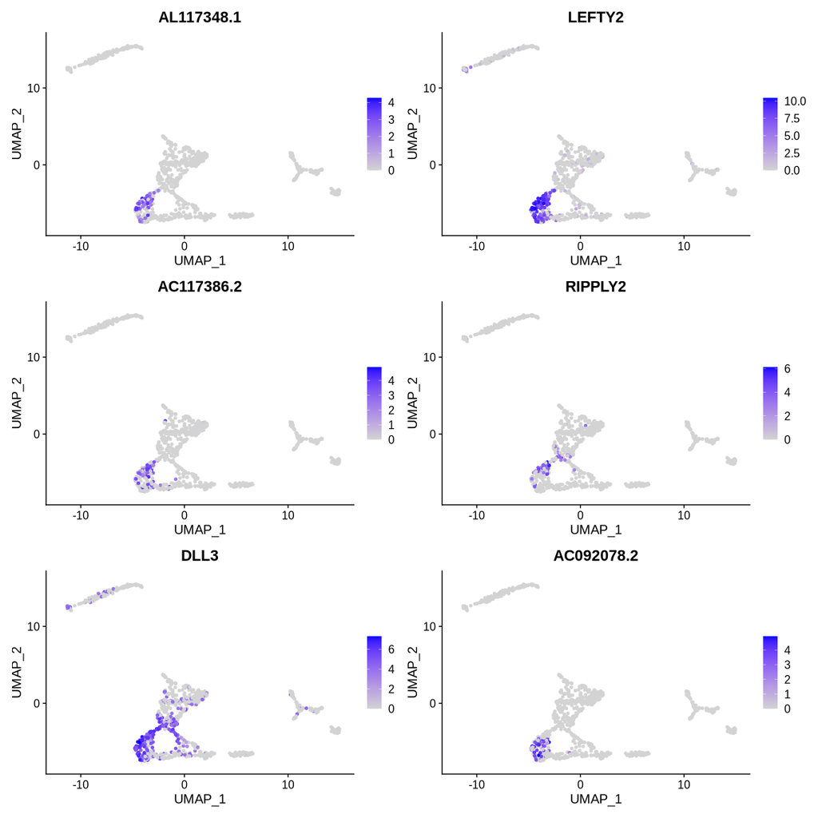

```r
top <- head(rownames(markers), n=6)
FeaturePlot(object=object,
            features=top)
```

### Discover the PGCs

Are there Primordial Germ Cells in this dataset? Hint: look for expression of NANOS3

- Bonus task: Look into docs of the function for the argument to plot the cells in order of expression. That way cells with zero expression will not obscure cells with high expression

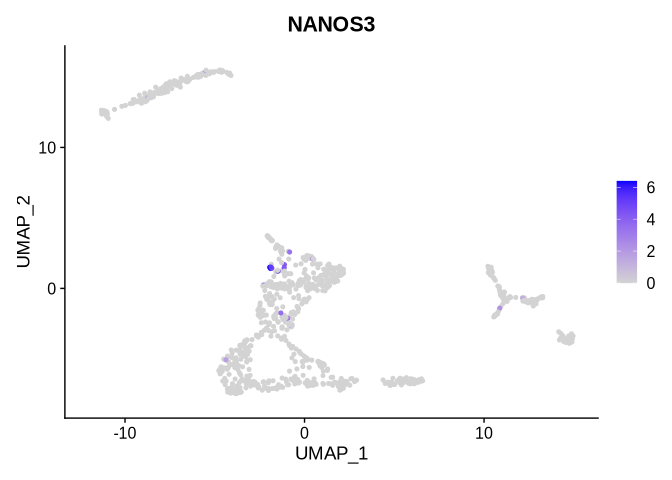

```r
FeaturePlot(object=object,
            features=c("NANOS3"))
```

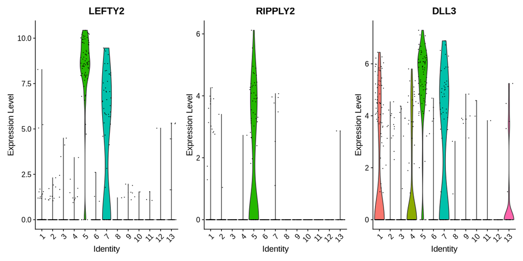

```r
VlnPlot(object,
        features=c("LEFTY2", "RIPPLY2", "DLL3"))
```

Q: Are the marker genes exclusively expressed in your cluster?

## Volcano plot

[Volcano plots](https://training.galaxyproject.org/training-material/topics/transcriptomics/tutorials/rna-seq-viz-with-volcanoplot/tutorial.html) are commonly used to display the results of RNA-seq or other omics experiments. A volcano plot is a type of scatterplot that shows statistical significance (P value) versus magnitude of change (fold change). It enables quick visual identification of genes with large fold changes that are also statistically significant. These may be the most biologically significant genes. In a volcano plot, the most upregulated genes are towards the right, the most downregulated genes are towards the left, and the most statistically significant genes are towards the top.

### Make a volcano plot between your cluster and cluster 13

We will need to install and load two more R packages and write a small script to make a volcano plot, as there is no volcano plot available in Seurat.

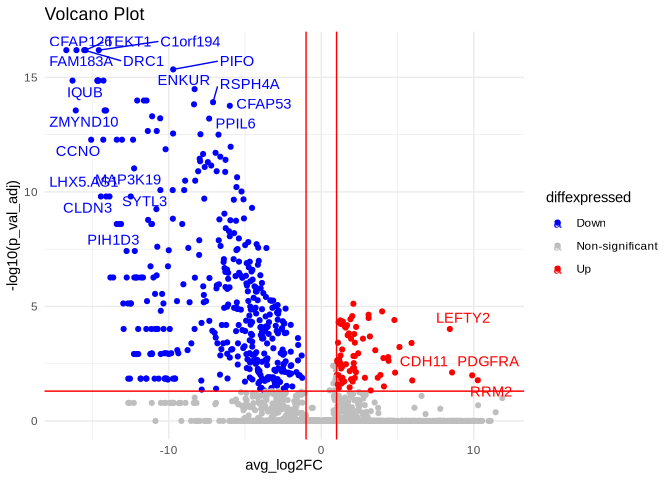

```r
library(ggplot2)
library(ggrepel)

## Calculate the DEGs between clusters 5 and 13
deTab <- FindMarkers(object=object,
                     ident.1=5,
                     ident.2=13,
                     min.pct=0.25)

# Add a column to to the table store whether a gene is Up-regulated, Down-regulated or the change is Non-significant
# The levels of average log fold change and he adjusted P-value are used to decide on the above
deTab$diffexpressed <- "Non-significant"
deTab$diffexpressed[deTab$avg_log2FC > 1 & deTab$p_val_adj < 0.05] <- "Up"
deTab$diffexpressed[deTab$avg_log2FC < -1 & deTab$p_val_adj < 0.05] <- "Down"

# In the
deTab$delabel <- NA
deTab$delabel[deTab$p_val_adj<0.05] <- rownames(deTab)[deTab$p_val_adj<0.05]
ggplot(data=deTab, aes(x=avg_log2FC, y=-log10(p_val_adj), col=diffexpressed, label=delabel)) +
        ggtitle("Volcano Plot") +
        geom_point() +
        theme_minimal() +
        geom_text_repel(max.overlaps = 10) +
        scale_color_manual(values=c("blue", "gray", "red")) +
        geom_vline(xintercept=c(-1, 1), col="red") +
        geom_hline(yintercept=-log10(0.05), col="red")
```

## Heatmap

### Markers for all clustes

If you are out of gene set ideas to plot on heatmap, calculate the markers for all clusters and select the top 2 for each of them

```r
markers <- FindAllMarkers(object=object,
                          only.pos=TRUE,
                          min.pct=0.25,
                          logfc.threshold=0.25)
top <- markers %>%
            group_by(cluster) %>%
            top_n(n=2,
                  wt=avg_log2FC)
head(top)
```

```
## # A tibble: 6 × 7
## # Groups:   cluster [3]
##      p_val avg_log2FC pct.1 pct.2 p_val_adj cluster gene
##      <dbl>      <dbl> <dbl> <dbl>     <dbl> <fct>   <chr>
## 1 6.70e-63       4.69 0.592 0.059  3.85e-58 1       CDX1
## 2 1.20e-31       4.56 0.483 0.107  6.93e-27 1       AP000943.2
## 3 2.67e-59       5.80 0.419 0.011  1.54e-54 2       IDO1
## 4 2.77e-28       4.28 0.295 0.026  1.59e-23 2       CNTN1
## 5 2.42e-59      16.1  0.338 0      1.39e-54 3       CYTIP
## 6 3.81e-57      14.6  0.325 0      2.19e-52 3       STAP1
```

### Filter and save the markers

We like to filter the results so we keep genes with `pct.1>0.6` and `p_val_adj<0.05`. Note you can do the same filtering by just sorting the corresponding columns in the all_markers table

```r
write.table(x = markers,
            file = "makrers.tsv",
            sep = "\t",
            quote = FALSE,
            row.names=FALSE)

filtered <- markers %>%
                  filter(pct.1>0.6, p_val_adj<0.05)
write.table(x = filtered,
            file = "filtered_makrers.tsv",
            sep = "\t",
            quote = FALSE,
            row.names=FALSE)
```

### Plot the set of genes on heatmap using Seurat function DoHeatmap

In this case the top 2 genes for each cluster (so 2*13=26 in total) are used

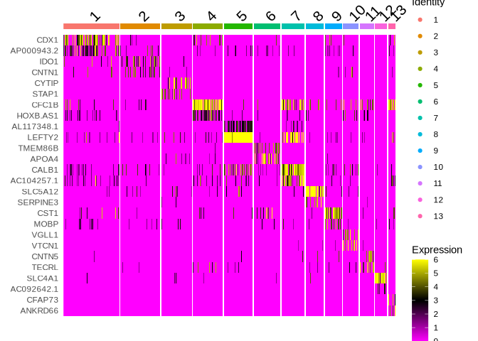

```r
DoHeatmap(object=object,
          features=top$gene,
          slot='data')
```

### Plot the set of genes on heatmap

The build-in heatmap function from Seurat leaves some things to be desired. First, it plots every cell individually, which clutters the plot with unnecessary info about each cell. Taking the average for each cluster would render a cleaner output. Second, it is difficult to further customize. For that reason we will write a few lines of code and create our own heatmap

- We will use `heatmap.2` function from library `gplots`

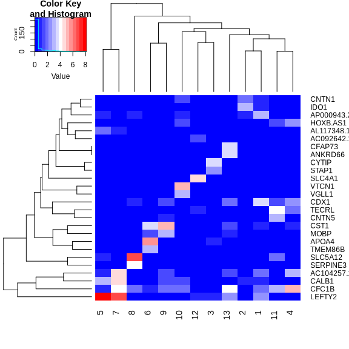

```r
library(gplots)
## Calculate the per cluster mean expression
groupIdentity <- Idents(object=object)
rawCounts <- GetAssayData(object=object, layer="counts")#, slot='scale.data')

## Substiture cell ID with cluster ID
colnames(rawCounts) <- groupIdentity

meanDF <- do.call(cbind, lapply(levels(groupIdentity), function(id){
   groupCounts <- rawCounts[, colnames(rawCounts) == id]
   df <- data.frame( c = apply(groupCounts, 1, mean))
   df <- log(df+1)
   colnames(df) <- id
   return(df)
}))

meanDF_select <- as.matrix(meanDF[top$gene, ])
heatmap.2(meanDF_select,
          col="bluered",
          trace = "none")
```

### Plot again without the dendrogram for the genes (rows)

- Bonus task: Can you plot plot the rows but not columns dendrogram

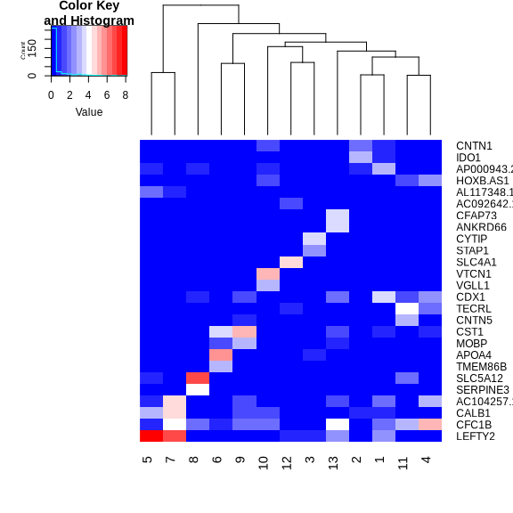

```r
heatmap.2(meanDF_select,
          col="bluered",
          trace = "none",
          dendrogram='column')
```

### Keep the original order for the genes in your heatmap

You may want to keep the order of the genes as provided, while still reorder the clusters

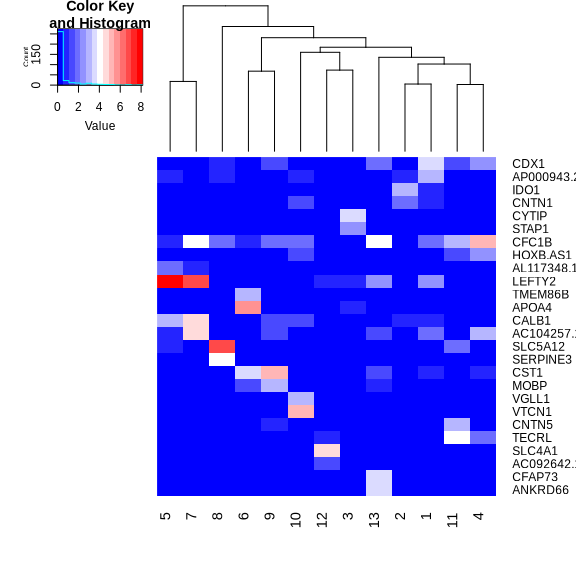

```r
heatmap.2(meanDF_select,
          col="bluered",
          trace = "none",
          dendrogram='column',
          Rowv=FALSE,
          Colv=TRUE)
```

### Z-score values heatmap

In statistics, the [standard score](https://en.wikipedia.org/wiki/Standard_score), or z-score, is the number of standard deviations by which the value of a raw score (i.e., an observed value or data point) is above or below the mean value of what is being observed or measured. Raw scores above the mean have positive standard scores, while those below the mean have negative standard scores.

- If `scale="row"` (or `scale="col"`) the rows (columns) are scaled to have mean zero and standard deviation one. There is some empirical evidence from genomic plotting that this is useful.

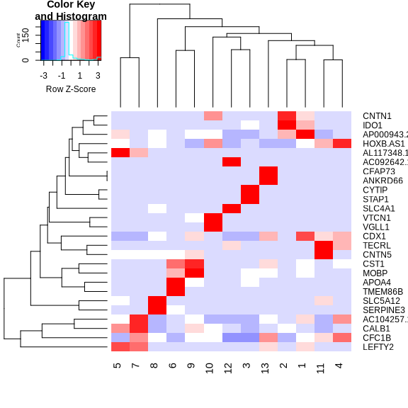

```r
heatmap.2(meanDF_select,
          col="bluered",
          trace='none',
          scale='row')
```

Q: What are the implications of applying scaling? How do you interpret the heatmap now?

### Plot the top 100 most variable genes of the dataset

In the seurat object, we have identified genes that exhibit high cell-to-cell variation in the dataset (i.e, they are highly expressed in some cells, and lowly expressed in others). The genes are sorted on Standardized Variance, a metric of variation.

We will extract the top 100 most variable genes and plot them on a heatmap. This can provide an interesting insight on the genes that drive the variation in the dataset

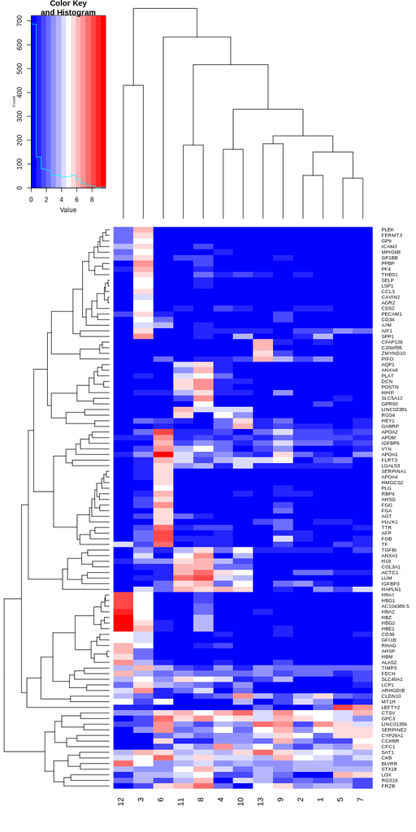

```r
top100 <- head(VariableFeatures(object), 100)
meanDF_select <- as.matrix(meanDF[top100, ])

heatmap.2(meanDF_select,
          col="bluered",
          trace = "none")
```

Qs: Do you think all of the 100 genes are biologically relevant

## Functional enrichment analysis

Performs functional enrichment analysis, also known as over-representation analysis (ORA) or gene set enrichment analysis, on input gene list. It maps genes to known functional information sources and detects statistically significantly enriched terms.

### Enrichment analysis on DEGs of our cluster

DEGs table is already sorted on p_val_adj. Use the top 100 genes to perform the analysis using gprofiler2

```r
library(gprofiler2)

top_genes_my_cluster <- markers %>%
                        filter(cluster==5) %>%
                        select(gene) %>%
                        head(n=100) %>%
                        rownames()

gost_results <- gost(query = top_genes_my_cluster,
                     organism = "hsapiens",
                     ordered_query = TRUE,
                     user_threshold = 0.05,
                     domain_scope = "annotated",
                     sources = c('GO:BP', 'GO:MF', 'GO:CC', 'KEGG', 'REAC', 'TF'))

## Drop parents column
terms_table <- gost_results$result %>% dplyr::select(-parents)

## Save in file
write.table(x = terms_table,
            file = "enrichment_analysis.tsv",
            sep = "\t",
            quote = FALSE,
            row.names = FALSE)
```

### Enrichment analysis using the web service of gProfiler

You can easily perform an enrichment analysis on your favorite list of genes using the [g:Profiler web server](https://biit.cs.ut.ee/gprofiler/gost).